# Machine Learning

### TicTacToe using Reinforcement Learning - Temporal Difference Method

#### Mageshwaran Anbazhagan

The project is about training an agent to play TicTacToe game successfully. The game is played by two players and each is assigned with a piece, either "X" or a "O". The agent is considered to the first player in this case, and performs the first move. The game terminates when the primary diagonal or secondary diagonal or entire row or entire column corresponds to a single player. If none of the instances or column converge to a winner, the game is drawn, with the basic overview of the game rules and procedure the agent is trained in the below part of the code using Temporal Difference Method (Reinforcement Learning).

The temporal difference method uses the value stored for the each action from the current state to train the agent make the best move. The value for the action is provided by using the following formula,

V(St) = V(St) + η[V(St+1) – V(St)]

where η, is the learning rate of the method. The value of the current state is determined by value from the future state. There is a reward provided to the model upon completion of the game. If the model wins the game a reward of "1" is provided to the state where the model declares itself as the winner and from there it backpropagates to update the state it took to reach the final state. Similarly, the model is given a "0" reward when it loses a game, but when there is no more move available and there is no clear winner, the game is considered to be drawn and the agent needs to be rewarded for the current state and thus a "0.6" is given. A slight advantage is given to the agent for arriving to the draw state, as the agent is trained to be more defencive and avoid losing the game.

# Player 1 as agent with non-learning player 2

The below section of the code import all the packages required to train the agent to play the TicTacToe game. With the help of numpy package, the list of values are converted to an array by which the environment for the game is setup. The random package helps in randomizing the next step of the player, finally the matplotlib.pyplot package aids in creating the visual graphics to better understand the learning curve or performance of the agent over the games played.

```python
import numpy as np
import random
import matplotlib.pyplot as plt
import seaborn as sns
```

### Determining the position which are available in the board environment

In the positionAvailable function defined below, the positions which are yet to be filled are identified and returned as list to the calling function. A loop with the range of 9 is iterated and checked for zeros in it. The board can contain only three values, 1 or "X" being agent, -1 or "O" being player 2, and "0" being empty cells to be occupied. If the cell contain a zero in it, those cell indexes are taken and appended to a list, which is then returned to the calling function

```python
def positionAvailable():
    posAvailable = []
    for i in range(0,9):
        if board[i] == 0:
            posAvailable.append(i+1)
    return posAvailable
```

### Evaluating the presence of a winner

Once the game is started, the agent and the player 2 start battling against each other to showcase their upper hand on each other, to determine who have crossed the line before the other, the checkWinner() function is used. Inside this function, a gameOver flag with value "0" is initialized to indicate the presence of a winner. The list of values in the board environment is converted to a 3X3 array with the help of numpy package and calculated for the diagonal, row and column level values. If any of the three consecutive cell have the same player or agent values, they are considered to be the winner. If the environment predicts a winner, the gameOver flag is set to "1" and the value is then returned to the calling function.

```python
def checkWinner():
    gameOver = 0
    boardMatrix = np.array(board)
    shape = (3,3)
    boardMatrix = boardMatrix.reshape(shape)
    primaryDiagonal = np.trace(boardMatrix) ** 2
    secondaryDiagonal = np.sum(np.fliplr(boardMatrix).diagonal()) ** 2
    firstRow = np.sum(boardMatrix[0]) ** 2
    secondRow = np.sum(boardMatrix[1]) ** 2
    thirdRow = np.sum(boardMatrix[2]) ** 2
    firstColumn = np.sum(boardMatrix[:,0]) ** 2
    secondColumn = np.sum(boardMatrix[:,1]) ** 2
    thirdColumn = np.sum(boardMatrix[:,2]) ** 2
    if 9 in {primaryDiagonal, secondaryDiagonal, firstRow, secondRow, thirdRow, firstColumn, secondColumn, thirdRow}:
        gameOver = 1
    return gameOver
```

### Enter the game to train the agent

```python
def startGame():
    result = 0
    for i in range(0,9):
        if  result == 0:
            posAvailable = positionAvailable()
            for j in range(0,len(posAvailable)):
                if j == 0:
                    maxVal = boardState[posAvailable[j]-1]
                    maxIndex = posAvailable[j]
                elif maxVal < boardState[posAvailable[j]-1]:
                    maxVal = boardState[posAvailable[j]-1]
                    maxIndex = posAvailable[j]
            turnOverP1 = 1
            turnOverP2 = 1
            if len(posAvailable) > 0:
                if i % 2 == 0:
                    while turnOverP1 == 1:
                        if i == 0:
                            positionmetriw = maxIndex
                        player1Choice = maxIndex
                        if player1Choice in posAvailable:
                            playerState.append(player1Choice)
                            board[player1Choice - 1] = 1
                            turnOverP1 = 0
                else:
                    while turnOverP2 == 1:
                        player2Choice = random.randint(1,9)
                        if i == 1:
                            positionmetril = player2Choice
                        if player2Choice in posAvailable:
                            board[player2Choice -1] = -1
                            turnOverP2 = 0
        result = checkWinner()
        if result == 1:
            if i % 2 == 0:
                stateVal(1.0)
                i = 8
                positionMetricWon[positionmetriw] += 1
                return 1
            else:
                stateVal(0.0)
                i = 8
                positionMetricLost[positionmetril] += 1
                return 0
        elif ((i == 9) & (result == 0)):
            stateVal(0.6)
            return 0.6
```

### Assisting the agent to decide his future moves

The stateVal() function takes in the reward value from the startGame() function and updates the boardState data set of the agent, such that the agent learns from his mistakes. The function also gets the states of the agent upon completion of the game. Using the playerState list, the function backpropagates and updates the value in the boardState data set with the formula provided in the top. The η in the formula is taken to be **0.4**, which is taken randomnly.

```python
def stateVal(reward):
    flag = 0
    eeta = 0.4
    for i in reversed(playerState):
        if flag == 0:
            boardState[i-1] = reward
            flag = 1
            update = i
        else:
            boardState[i-1] = boardState[i-1] + eeta * (boardState[update - 1] - boardState[i-1])
            update = i
```

### Initialization and beginning of the training

The global values are initialized in this section of the code, which are used in the later part to train the agent as well as provided result statistics. This section consists of a loop which iterates over n number of times to train the agent. Everytime the game is begun, the board environment alone is reset, with boardState of the agent staying intact to help him assist in the next game. The game statistics are stored in the player1metric, player2metric, drawmetric list. The count of the wins are also stored under player1metri, player2metri, drawmetri list created inside this section.

```python
boardState = [0,0,0,0,0,0,0,0,0]
positionMetricWon = {1:0,2:0,3:0,4:0,5:0,6:0,7:0,8:0,9:0}
positionMetricLost = {1:0,2:0,3:0,4:0,5:0,6:0,7:0,8:0,9:0}
player1 = 0
player2 = 0
draw = 0
player1metric = []
player2metric = []
drawmetric = []
player1metri = []
player2metri = []
drawmetri = []
iterationmetric = list(range(1, 401))
Categories = ["Player1","Player2","Draw"]
for i in range(1,401):
    board = [0,0,0,0,0,0,0,0,0]
    reward = 0
    playerState = []
    answer = startGame()
    if answer == 1:
        player1 += 1
    elif answer == 0:
        player2 += 1
    else:
        draw += 1
    player1metric.append(round((player1/i) * 100,2))
    player2metric.append(round((player2/i) * 100,2))
    drawmetric.append(round((draw/i) * 100,2))
    player1metri.append(player1)
    player2metri.append(player2)
    drawmetri.append(draw)
```

### Converting the 1 and -1 to X and O's

```python
boardMatrix = np.array(board)
boardMatrix = np.where(boardMatrix == 1, "X", boardMatrix)
boardMatrix = np.where(boardMatrix == "-1", "O", boardMatrix)
boardMatrix = np.where(boardMatrix == "0", " ", boardMatrix)
shape = (3,3)
boardMatrix = boardMatrix.reshape(shape)
```

### Statistical Analysis on the performance of the agent

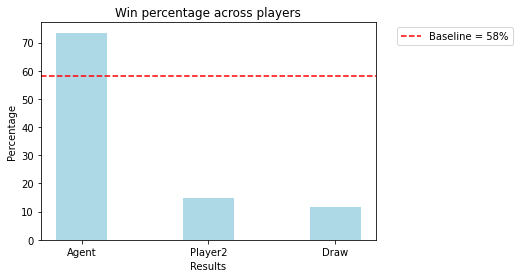

```python
metricDictionary = {"Agent":player1metric[-1],"Player2":player2metric[-1],"Draw":drawmetric[-1]}
categories = list(metricDictionary.keys())
values = list(metricDictionary.values())
plt.bar(categories, values, color ='lightblue',
        width = 0.4)
plt.xlabel("Results")
plt.ylabel("Percentage")
plt.title("Win percentage across players")
plt.axhline(y=58,color='red',linestyle='--',label='Baseline = 58%')
plt.legend(bbox_to_anchor=(1.05, 1.0), loc='upper left')
plt.show()
```

### Performance of the agent visualized after each game

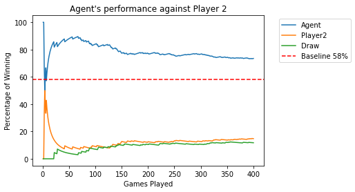

```python
plt.plot(iterationmetric, player1metric, label = "Agent")
plt.plot(iterationmetric, player2metric, label = "Player2")
plt.plot(iterationmetric, drawmetric, label = "Draw")
plt.xlabel("Games Played")
plt.ylabel("Percentage of Winning")
plt.title("Agent's performance against Player 2")
plt.axhline(y=58,color='red',linestyle='--',label='Baseline 58%')
plt.legend(bbox_to_anchor=(1.05, 1.0), loc='upper left')
plt.show()
```

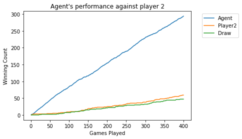

```python
plt.plot(iterationmetric, player1metri, label = "Agent")
plt.plot(iterationmetric, player2metri, label = "Player2")
plt.plot(iterationmetric, drawmetri, label = "Draw")
plt.xlabel("Games Played")
plt.ylabel("Winning Count")
plt.title("Agent's performance against player 2")
plt.legend(bbox_to_anchor=(1.05, 1.0), loc='upper left')
plt.show()
```

Similarly, a line graph using the count alone is plotted to observe the performance of the agent. The count is taken along Y axis and games played along the X axis. It is seen clearly, that the blue line kept increasing steadily over the games played and increased the probability of the agent to be on the winning side.

```python
print(positionMetricWon)
print(positionMetricLost)
```

```
{1: 54, 2: 17, 3: 36, 4: 33, 5: 52, 6: 5, 7: 58, 8: 16, 9: 23}
{1: 11, 2: 3, 3: 7, 4: 4, 5: 14, 6: 3, 7: 6, 8: 8, 9: 3}
```

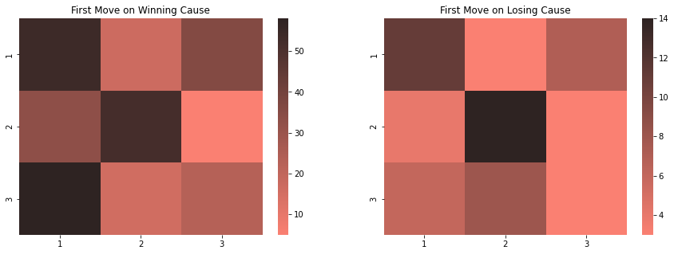

```python
tempList=list(positionMetricWon.values())
numpyArray = np.array(tempList)
numpyArray = np.reshape(numpyArray,(3,3))
x_axis_labels = [1,2,3] # labels for x-axis
y_axis_labels = [1,2,3]
cc = sns.color_palette("dark:salmon_r", as_cmap=True)
plt.figure(figsize = [15,5])
plt.subplot(1, 2, 1)
plt.title("First Move on Winning Cause")
sns.heatmap(numpyArray, xticklabels=x_axis_labels, yticklabels=y_axis_labels,cmap=cc)

tempList=list(positionMetricLost.values())
numpyArray = np.array(tempList)
numpyArray = np.reshape(numpyArray,(3,3))
x_axis_labels = [1,2,3] # labels for x-axis
y_axis_labels = [1,2,3]
cc = sns.color_palette("dark:salmon_r", as_cmap=True)
plt.subplot(1, 2, 2)
plt.title("First Move on Losing Cause")
sns.heatmap(numpyArray, xticklabels=x_axis_labels, yticklabels=y_axis_labels,cmap=cc)
```